# # ArundelStat Analyst Interview Test Dataset

Prasann Ranade

2024-10-23

## Aim: Utilize R and data viz to highlight trends/variations and inform areas of focus

1. Data Cleaning and Preparation
2. Exploratory Data Analysis
3. Predictive Modeling
4. Interpret Insights
5. Organize Outputs

## 1. Data Cleaning and Preparation

### 1.1 Overall Data Structure

Metrics Distribution  
- issue background (issue ID, status, summary, description)  
- reporting info (full name, email, report method, report source) - request info (request ID, request title, issue type, department, subdivision, contact person)  
- timeline (updated_at, created_at, acknowledged_at, reopened_at, closed_at, days until acknowledge, days until closed)  
- geography (address, latitude, longitude)

- continuous: Rating, Lat, Long, updated_at, created_at, acknowledged_at, reopened_at, closed_at, DaysUntilAcknowledged, DaysUntilClosed
- categorical: IssueStatus, Summary, Description, IssueAddress, RequestTypeTitle, IssueType, Department, Subdivision, ContactGroupPerson, ReportMethod, FullName, Email, ReportSource
- factors: IssueStatus, RequestTypeTitle, IssueType, Department, Subdivision, ContactGroupPerson, ReportMethod, ReportSource, Rating

```r
# read in, head, info
data <- read_xlsx("SCF_Stats_Issues-Archived_2024-10-14.xlsx")

# columns are either of type double, character, or datetime and data types make sense
glimpse(data) # 109131 entries x 25 features
```

```
## Rows: 109,131
## Columns: 25
## $ IssueID               <dbl> 3011399, 2841817, 2845868, 2850590, 2857020, 288…
## $ IssueStatus           <chr> "Archived", "Archived", "Archived", "Archived", …
## $ Summary               <chr> "If you're driving south on 175, the light that'…
## $ Description           <chr> "Green light out for those headed SE", "Street l…
## $ IssueAddress          <chr> "2753 Annapolis Rd Hanover MD 21076, USA", "Grah…
## $ RequestTypeID         <dbl> 17402, 17402, 17402, 17402, 17402, 17402, 17402,…
## $ RequestTypeTitle      <chr> "Test Issue", "Test Issue", "Test Issue", "Test …
## $ IssueType             <chr> NA, NA, NA, NA, NA, NA, NA, "Lost Pet\r\n", "Los…
## $ Department            <chr> NA, NA, NA, NA, NA, NA, NA, "Animal Control", "A…
## $ Subdivision           <chr> NA, NA, NA, NA, NA, NA, NA, "N/A", "N/A", "N/A",…
## $ ContactGroupPerson    <chr> NA, NA, NA, NA, NA, NA, NA, "animal-control-lost…
## $ ReportMethod          <chr> "direct", "direct", "direct", "direct", "direct"…
## $ Rating                <dbl> 4, 2, 2, 2, 4, 2, 3, 4, 3, 4, 3, 3, 3, 3, 3, 3, …
## $ Lat                   <dbl> 39.13894, 39.13728, 38.92705, 39.17884, 38.97938…
## $ Long                  <dbl> -76.75363, -76.70333, -76.54951, -76.69296, -76.…
## $ updated_at            <dttm> 2016-11-15 15:04:01, 2016-11-15 15:04:00, 2016-…
## $ created_at            <dttm> 2016-10-19 12:06:08, 2016-08-26 14:36:42, 2016-…
## $ acknowledged_at       <dttm> NA, NA, NA, NA, NA, NA, NA, 2024-08-06 09:51:39…
## $ reopened_at           <dttm> NA, NA, NA, NA, NA, NA, NA, NA, NA, NA, NA, NA,…
## $ closed_at             <dttm> 2016-11-15 15:03:59, 2016-11-15 15:03:59, 2016-…
## $ DaysUntilAcknowledged <dbl> NA, NA, NA, NA, NA, NA, NA, 2, 0, 0, 0, 1, 1, 2,…
## $ DaysUntilClosed       <dbl> 27, 81, 79, 78, 63, 0, 0, 14, 14, 14, 14, 14, 14…
## $ FullName              <chr> "An anonymous SeeClickFix user", "An anonymous S…
## $ Email                 <chr> "anonymous@seeclickfix.com", "anonymous@seeclick…
## $ ReportSource          <chr> NA, NA, NA, NA, NA, NA, NA, "Portal", NA, "Web -…
```

```r
# overview of summary statistics for reference
# summary(data)


# view(dfSummary(elicit_df_maternal_filtered[,c(1:23,924)]))
# summary()
```

### 1.2 Missing Data

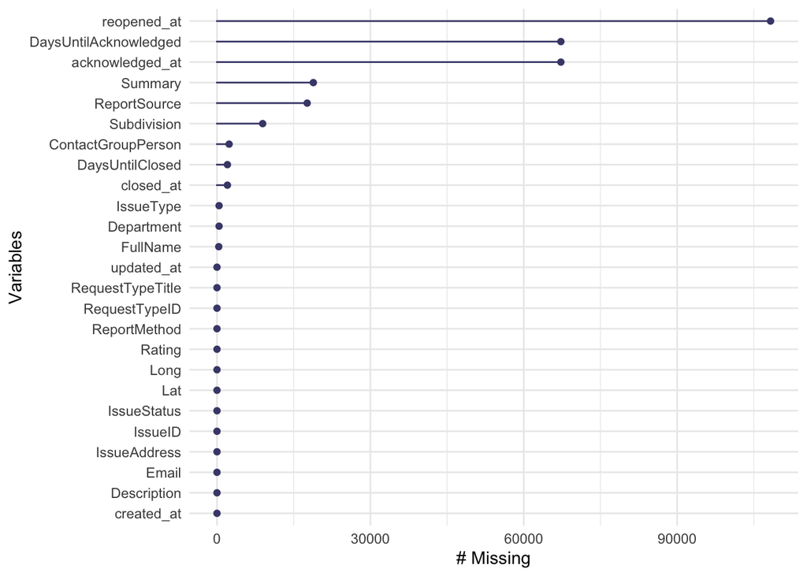

```r
# view missing data using visdat and naniar packages
# vis_dat(data, warn_large_data = FALSE)

gg_miss_var(data) # visual comparison of missingness by feature
```

```r
miss_var_summary(data) # percentage missingness by feature
```

```
## # A tibble: 25 × 3
##    variable              n_miss pct_miss
##    <chr>                  <int>    <num>
##  1 reopened_at           108276   99.2
##  2 acknowledged_at        67265   61.6
##  3 DaysUntilAcknowledged  67265   61.6
##  4 Summary                18844   17.3
##  5 ReportSource           17638   16.2
##  6 Subdivision             8936    8.19
##  7 ContactGroupPerson      2374    2.18
##  8 closed_at               2039    1.87
##  9 DaysUntilClosed         2039    1.87
## 10 IssueType                407    0.373
## # ℹ 15 more rows
```

```r
miss_case_table(data)
```

```
## # A tibble: 12 × 3
##    n_miss_in_case n_cases pct_cases
##             <int>   <int>     <dbl>
##  1              0     247  0.226
##  2              1   26297 24.1
##  3              2   11593 10.6
##  4              3   46344 42.5
##  5              4   18316 16.8
##  6              5    4781  4.38
##  7              6     863  0.791
##  8              7     594  0.544
##  9              8      59  0.0541
## 10              9      27  0.0247
## 11             10       9  0.00825
## 12             11       1  0.000916
```

### 1.3 Duplicated Data

- least distinct features, arranged by count: mostly in list of factorable features but also Description, FullName, IssueAddress, Summary
- why is there a mismatch in the number of distinct values for RequestTypeID and RequestTypeTitle?

```r
# check duplicates
n_distinct(data) #109131
```

```
## [1] 109131
```

```r
data %>%
  summarise_all(n_distinct) %>%
  gather(key = "Column", value = "DistinctCount") %>%
  arrange(DistinctCount)
```

```
## # A tibble: 25 × 2
##    Column             DistinctCount
##    <chr>                      <int>
##  1 IssueStatus                    1
##  2 ReportMethod                   8
##  3 ReportSource                   8
##  4 Department                    10
##  5 Subdivision                   10
##  6 ContactGroupPerson            19
##  7 Rating                        19
##  8 IssueType                     52
##  9 RequestTypeID                 60
## 10 RequestTypeTitle              74
## # ℹ 15 more rows
```

```r
factors <- c("RequestTypeTitle", "IssueType", "Department", "Subdivision", "ContactGroupPerson", "ReportMethod", "ReportSource", "Rating")

for (col in factors) {
  cat("\nColumn:", col)
  sorted_table <- head(sort(table(data[[col]]), decreasing = TRUE))
  print(sorted_table)
}
```

```
##
## Column: RequestTypeTitle
## Request a new Recycling Container Report Missed Curbside Collection
##                             21561                             17300
##        Schedule Bulk Metal Pickup                           Pothole
##                             10670                              5790
##                Building Violation   Abandoned Vehicle on the Street
##                              4750                              3554
##
## Column: IssueType
## Request New Recycling Container      Missed Curbside Collection
##                           21561                           17502
##      Schedule Bulk Metal Pickup                         Pothole
##                           10670                            5790
##              Building Violation                   Tree Trimming
##                            4750                            3760
##
## Column: Department
##               DPW               I&P Health Department    Animal Control
##             81998              9228              4242              3649
##            Police               P&Z
##              3554              2488
##
## Column: Subdivision
##     Waste Management             Highways      Code Complaince
##                52823                21328                11525
##                  N/A Police Non-Emergency  Traffic Engineering
##                 3649                 3554                 3338
##
## Column: ContactGroupPerson
## auto-populate into CassWorks       boh-admin@aacounty.org
##                        39624                        21328
##        pwspri00@aacounty.org                  Bill Bryant
##                        10670                         4750
##              Christina Braun         hdsodhf@aacounty.org
##                         4287                         4164
##
## Column: ReportMethod
##   direct    phone    other    email internal   walkin
##   108983       60       58       18        7        3
##
## Column: ReportSource
##        Portal        iPhone       Android  Web - Mobile Web - Desktop
##         51283         19390          8104          7850          4600
##         Other
##           191
##
## Column: Rating
##     2     3     4     5     1     6
## 64974 34606  6965  1153  1024   261
```

```r
head(sort(table(data$IssueAddress), decreasing = TRUE))
```

```
##
## 1758 Crownsville Rd Annapolis 21401, United States
##                                                241
##                           21401 Annapolis, MD, USA
##                                                179
##       44 Calvert St Annapolis 21401, United States
##                                                114
##     1758 Crownsville Rd Crownsville, MD 21032, USA
##                                                 72
##                         21060 Glen Burnie, MD, USA
##                                                 47
##                           21122 Pasadena, Maryland
##                                                 45
```